# Self-Organizing Map for dissimilarity matrices

#### Laura BENDHAIBA, Madalina OLTEANU, Nathalie VILLA-VIALANEIX

## Basic package description

To be able to run the SOM algorithm, you have to load the package called `SOMbrero`. The function used to run it is called `trainSOM()` and is detailed below.

**This documentation only considers the case of dissimilarity matrices.**

### Arguments

The `trainSOM` function has several arguments, but only the first one is required. This argument is `x.data` which is the dataset used to train the SOM. In this documentation, it is passed to the function as a matrix or a data frame. This set must be a dissimilarity matrix, i.e., a symmetric matrix of positive numbers, with zero entries on the diagonal.

The other arguments are the same as the arguments passed to the `initSOM` function (they are parameters defining the algorithm, see `help(initSOM)` for further details).

### Outputs

The `trainSOM` function returns an object of class `somRes` (see `help(trainSOM)` for further details on this class).

### Graphics

The following table indicates which graphics are available for a relational SOM.

| Type | Energy | Obs | Prototypes | Add | Super Cluster |
| --- | --- | --- | --- | --- | --- |
| no type | x |  |  |  |  |
| hitmap |  | x |  |  | x |
| color |  |  |  | x |  |
| lines |  |  | x | x | x2 |
| barplot |  |  | x | x | x2 |
| radar |  |  | x | x | x2 |
| pie |  |  |  | x | x2 |
| boxplot |  |  |  | x |  |
| 3d |  |  |  |  |  |
| poly.dist |  |  | x |  | x |
| umatrix |  |  | x |  |  |
| smooth.dist |  |  | x |  |  |
| words |  |  |  | x |  |
| names |  | x |  | x |  |
| graph |  |  |  | x | x |
| mds |  |  | x |  | x |
| grid.dist |  |  | x |  |  |
| grid |  |  |  |  | x |
| dendrogram |  |  |  |  | x |
| dendro3d |  |  |  |  | x |

In the “Super Cluster” column, a plot marked by “x2” means it is available for both data set variables and additional variables.

## Case study: the `lesmis` data set

The `lesmis` data set provides the coappearance graph of the characters of the novel Les Miserables (Victor Hugo). Each vertex stands for a character whose name is given by the vertex label. One edge means that the corresponding two characters appear in a common chapter in the book. Each edge also has a value indicating the number of coappearances. The `lesmis` data contain two objects: the first one `lesmis` is an `igraph` object (see [the igraph web page](http://igraph.sourceforge.net/)), with 77 nodes and 254 edges.

Further information on this data set is provided with `help(lesmis)`.

```r
data(lesmis)
lesmis
```

```
## IGRAPH U--- 77 254 --
## + attr: id (v/n), label (v/c), value (e/n)
```

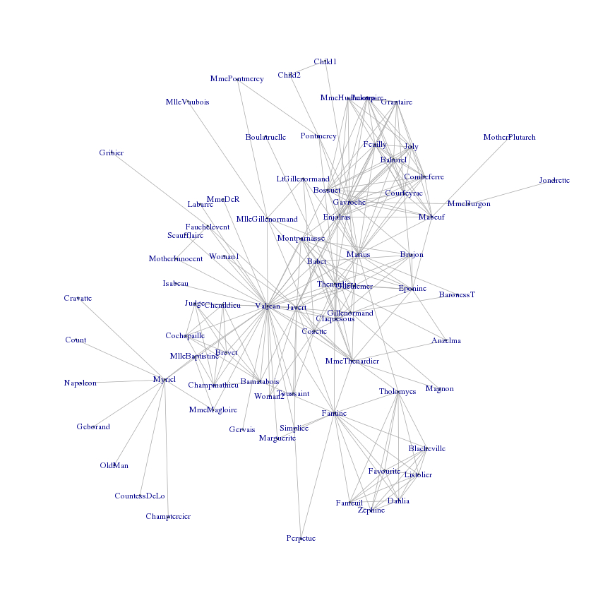

```r
plot(lesmis, vertex.size = 0)
```

[output not shown]

### Training the SOM

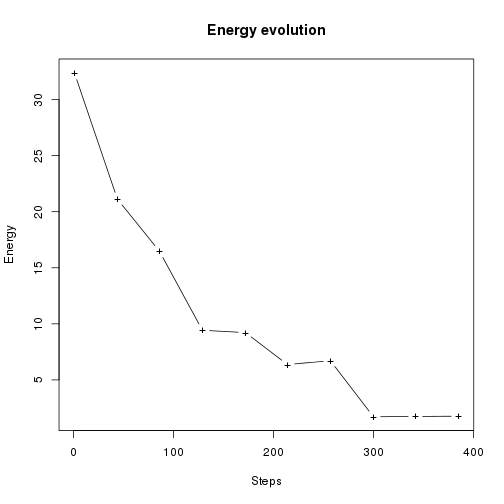

```r
set.seed(4031719)
mis.som <- trainSOM(x.data = dissim.lesmis, type = "relational", nb.save = 10)
plot(mis.som, what = "energy")
```

The dissimilarity matrix `dissim.lesmis` is passed to the `trainSOM` function as input. As the SOM intermediate backups have been registered (`nb.save=10`), the energy evolution can be plotted: it stabilized in the last 100 iterations.

### Resulting clustering

The clustering component provides the classification of each of the 77 characters. The `table` function is a simple way to view data distribution on the map.

```r
mis.som$clustering
```

```
##           Myriel         Napoleon   MlleBaptistine      MmeMagloire
##               21               21               22               22
##     CountessDeLo         Geborand     Champtercier         Cravatte
##               21               21               21               21
##            Count           OldMan          Labarre          Valjean
##               21               21               17               17
##       Marguerite           MmeDeR          Isabeau          Gervais
##               18               23               17               18
##        Tholomyes        Listolier          Fameuil      Blacheville
##                1                1                1                1
##        Favourite           Dahlia          Zephine          Fantine
##                1                1                1                6
##    MmeThenardier       Thenardier          Cosette           Javert
##               11               15               13               20
##     Fauchelevent       Bamatabois         Perpetue         Simplice
##               25               24                6               11
##      Scaufflaire           Woman1            Judge     Champmathieu
##               23               25               24               24
##           Brevet       Chenildieu      Cochepaille        Pontmercy
##               24               24               24                7
##     Boulatruelle          Eponine          Anzelma           Woman2
##               15               15               15               17
##   MotherInnocent          Gribier        Jondrette        MmeBurgon
##               25               25                9                9
##         Gavroche     Gillenormand           Magnon MlleGillenormand
##                9               12               12               12
##     MmePontmercy      MlleVaubois   LtGillenormand           Marius
##               12               12               12                8
##        BaronessT           Mabeuf         Enjolras       Combeferre
##                7                3                5                4
##        Prouvaire          Feuilly       Courfeyrac          Bahorel
##                5                4                4                5
##          Bossuet             Joly        Grantaire   MotherPlutarch
##                5                5                5                3
##        Gueulemer            Babet       Claquesous     Montparnasse
##               14               14               20               14
##        Toussaint           Child1           Child2           Brujon
##               17                9                9               14
##     MmeHucheloup
##                5
```

```r
table(mis.som$clustering)
```

```
##
##  1  3  4  5  6  7  8  9 11 12 13 14 15 17 18 20 21 22 23 24 25
##  7  2  3  7  2  2  1  5  2  6  1  4  4  5  2  2  8  2  2  6  4
```

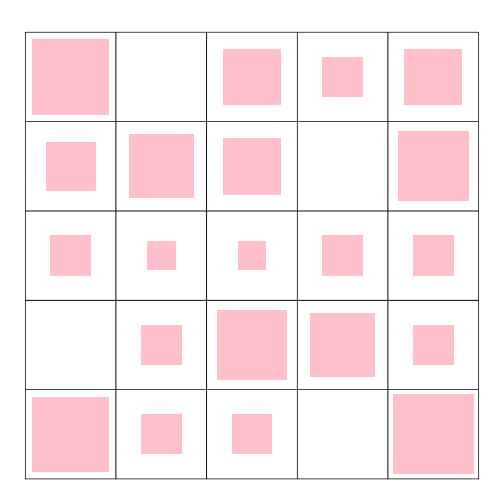

```r
plot(mis.som)
```

The clustering can be displayed using the `plot` function with `type=names`.

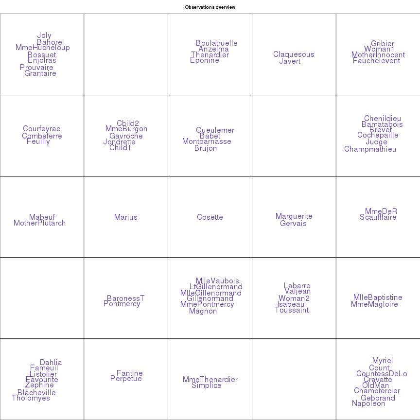

```r
plot(mis.som, what = "obs", type = "names")
```

or by sur-imposing the original igraph object on the map:

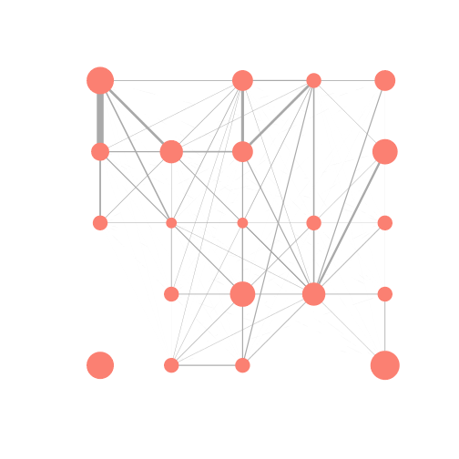

```r
plot(mis.som, what = "add", type = "graph", var = lesmis)
```

Clusters profile overviews can be plotted either with lines, barpot or radar.

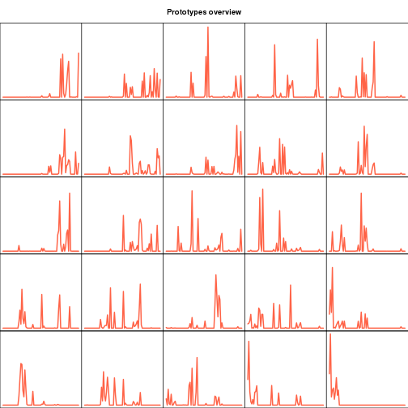

```r
plot(mis.som, what = "prototypes", type = "lines")
```

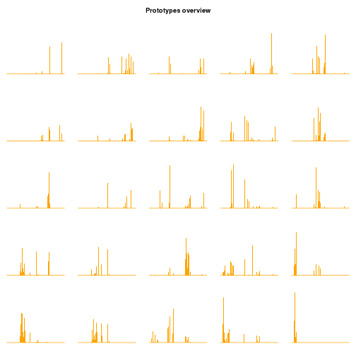

```r
plot(mis.som, what = "prototypes", type = "barplot")
```

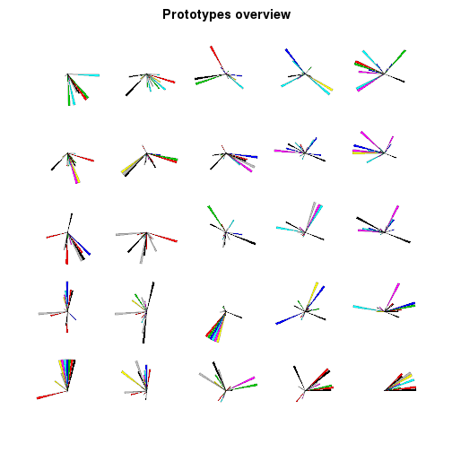

```r
plot(mis.som, what = "prototypes", type = "radar")
```

On these graphics, one variable is represented respectively with a point, a bar or a slice. It is therefore easy to see which variable affects which cluster.

To see how different the clusters are, some graphics show the distances between prototypes. These graphics have exactly the same behaviour as in the other SOM types.

- `"poly.dist"` represents the distances between neighboring prototypes with polygons plotted for each cell of the grid. The smaller the distance between a polygon's vertex and a cell border, the closer the pair of prototypes. The colors indicates the number of observations in the neuron (white is used for empty neurons);
- `"umatrix"` fills the neurons of the grid using colors that represent the average distance between the current prototype and its neighbors;
- `"smooth.dist"` plots the mean distance between the current prototype and its neighbors with a color gradation;
- `"mds"` plots the number of the neuron on a map according to a Multi Dimensional Scaling (MDS) projection;
- `"grid.dist"` plots a point for each pair of prototypes, with x coordinates representing the distance between the prototypes in the input space, and y coordinates representing the distance between the corresponding neurons on the grid.

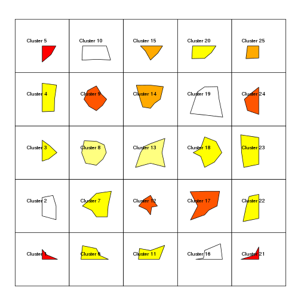

```r
plot(mis.som, what = "prototypes", type = "poly.dist", print.title = TRUE)
```

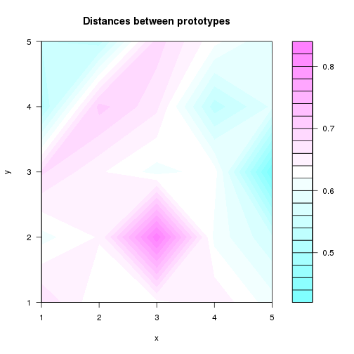

```r
plot(mis.som, what = "prototypes", type = "smooth.dist")
```

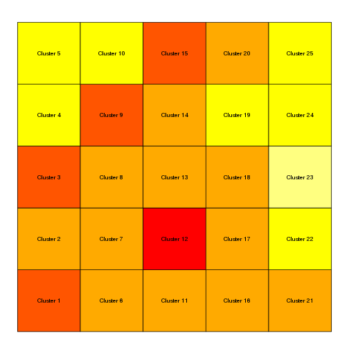

```r
plot(mis.som, what = "prototypes", type = "umatrix", print.title = TRUE)
```

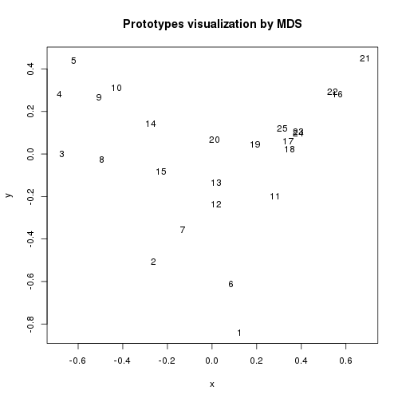

```r
plot(mis.som, what = "prototypes", type = "mds")
```

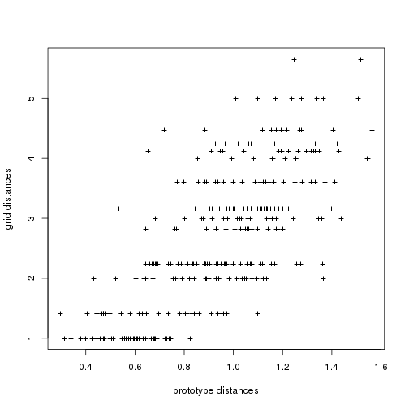

```r
plot(mis.som, what = "prototypes", type = "grid.dist")
```

Finally, with a graphical overview of the clustering

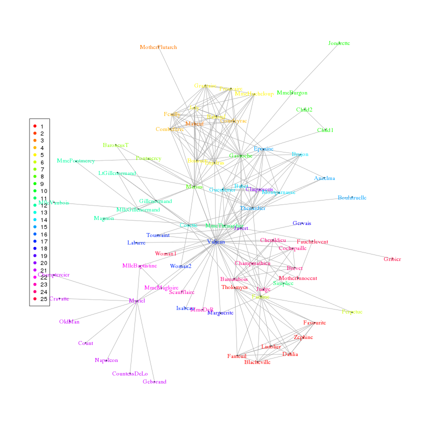

```r
plot(lesmis, vertex.label.color = rainbow(25)[mis.som$clustering], vertex.size = 0)
legend(x = "left", legend = 1:25, col = rainbow(25), pch = 19)
```

### Compute super clusters

As the number of clusters is quite important with the SOM algorithm, it is possible to perform a hierarchical clustering. First, let us have an overview of the dendrogram:

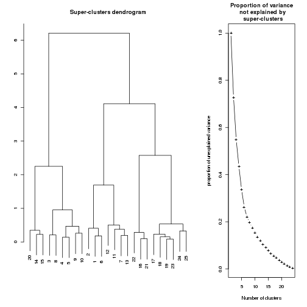

```r
plot(superClass(mis.som))
```

According to the proportion of variance explained by super clusters, 6 groups seem to be a good choice.

```r
sc.mis <- superClass(mis.som, k = 6)
summary(sc.mis)
```

```
##
##    SOM Super Classes
##      Initial number of clusters :  25
##      Number of super clusters   :  6
##
##
##   Frequency table
## 1 2 3 4 5 6
## 3 6 4 3 3 6
##
##   Clustering
##  1  2  3  4  5  6  7  8  9 10 11 12 13 14 15 16 17 18 19 20 21 22 23 24 25
##  1  1  2  2  2  1  3  2  2  2  3  3  3  4  4  5  6  6  6  4  5  5  6  6  6
```

```r
table(sc.mis$cluster)
```

```
##
## 1 2 3 4 5 6
## 3 6 4 3 3 6
```

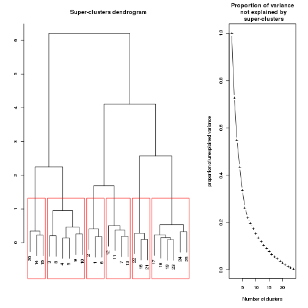

```r
plot(sc.mis)
```

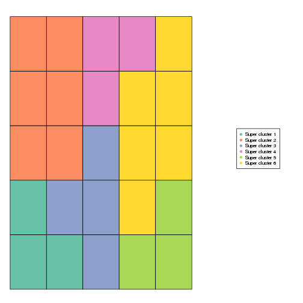

```r
plot(sc.mis, type = "grid", plot.legend = TRUE)
```

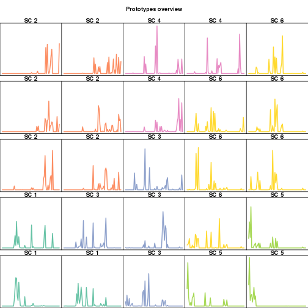

```r
plot(sc.mis, type = "lines", print.title = TRUE)
```

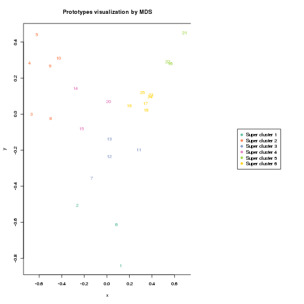

```r
plot(sc.mis, type = "mds", plot.legend = TRUE)
```

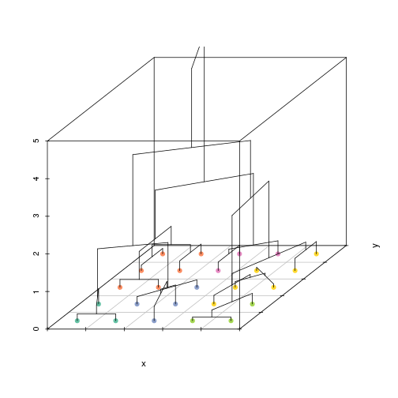

```r
plot(sc.mis, type = "dendro3d")
```

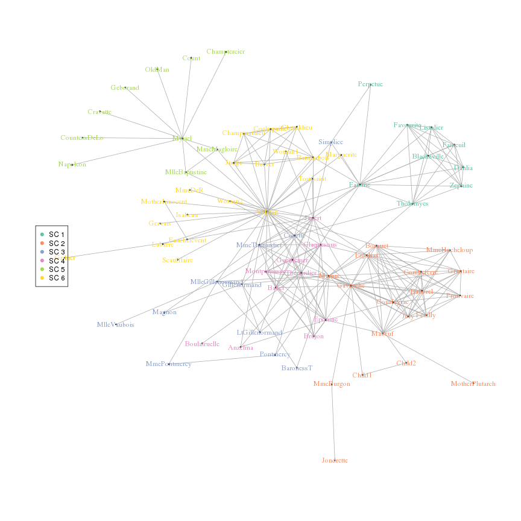

```r
plot(lesmis, vertex.size = 0, vertex.label.color = brewer.pal(6, "Set2")[sc.mis$cluster[mis.som$clustering]])
legend(x = "left", legend = paste("SC", 1:6), col = brewer.pal(6, "Set2"), pch = 19)
```

## Case study: the `iris` data set

The `iris` data set has already been used in the user friendly guide devoted to numeric data. To ensure the performance of the relational SOM, this section will compare the results obtained with both numerical and relational SOM. In the latter case, the matrix of pairwise distances between the observations is used as input data. Among all possibilities (see `help(dist)`), we here choose to use the `"mikowski"` distance of order 4 to enlarge large distances and reduce small ones.

```r
# run the numeric SOM
set.seed(4031730)
iris.som <- trainSOM(x.data = iris[, 1:4])
# run the relational SOM
iris.dist <- dist(iris[, 1:4], method = "minkowski", diag = TRUE, upper = TRUE,
    p = 4)
set.seed(7071731)
d.iris.som <- trainSOM(x.data = iris.dist, type = "relational")
```

The most important thing is to correctly separate the 3 flower species. The next 2 plots show the results with both SOM types.

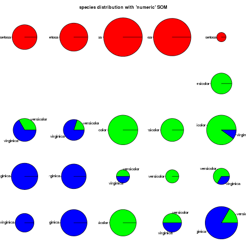

```r
plot(iris.som, what = "add", type = "pie", variable = iris$Species, main = "species distribution with 'numeric' SOM")
```

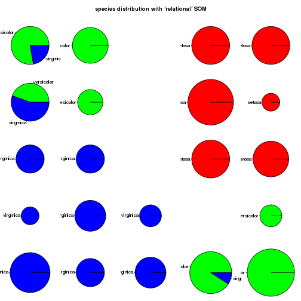

```r
plot(d.iris.som, what = "add", type = "pie", variable = iris$Species, main = "species distribution with 'relational' SOM")
```

As we chose a higher distance order in the `relational` SOM (argument `p=4`, whereas the Euclidean distance corresponds to a Minkowski distance of order 2), the result from the `relational` SOM show better separation of 'virginica' and 'versicolor' flowers: with the `numeric` SOM, these species are mixed in 7 neurons whereas they are mixed in 3 neurons with the `relational` SOM.